# Why code?

## Plain Text

### Copy and paste

non-pasteable

pasteable

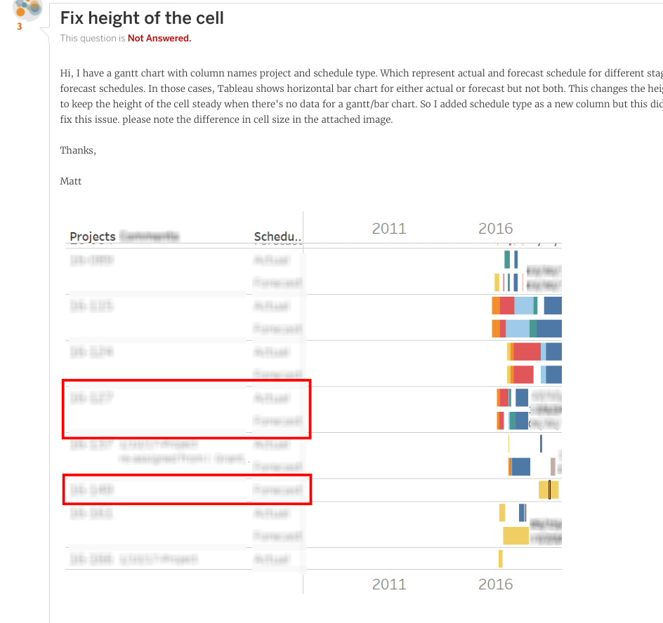

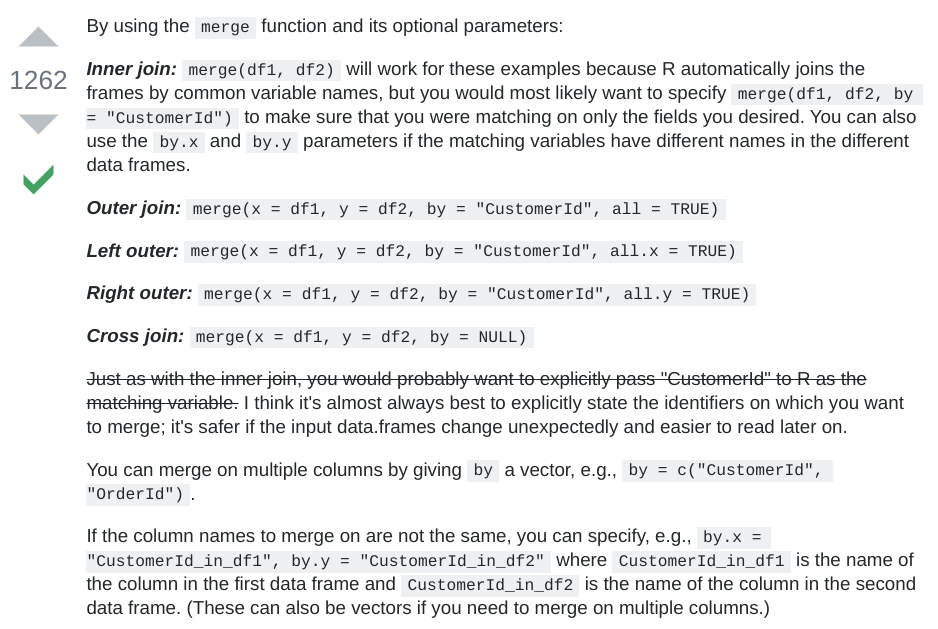

### Google / www.stackoverflow.com

## Open Source


## Powerful

[figure not shown]

## So what?

## Go beyond counting

Ask different kinds of questions

1. What did … ?
2. Why did … ?
3. What will … ?

## Look at relationships

```r
library(tidyverse)

test_cm <- act %>%
    filter(activity == "case management") %>%
    count(id) %>%
    inner_join(test, by = "id") %>%
    filter(test == "GED")

test_cm
```

```
## # A tibble: 105 x 5
##       id     n test  test_date  score
##    <int> <int> <chr> <date>     <dbl>
##  1     1    11 GED   2019-01-30 59.2
##  2     2     7 GED   2017-10-25 23.0
##  3     2     7 GED   2017-01-15  8.93
##  4     3     6 GED   2017-11-28 50.3
##  5     4     5 GED   2015-09-24 15.5
##  6     5     6 GED   2015-09-19 66.4
##  7     5     6 GED   2018-10-21 14.9
##  8     6     4 GED   2017-11-21 90.4
##  9     6     4 GED   2015-03-02 91.0
## 10     7     4 GED   2019-07-31 68.5
## # … with 95 more rows
```

## Look at relationships

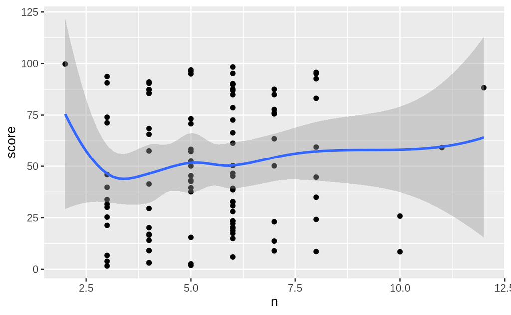

```r
test_cm %>%
    ggplot(aes(n, score)) +
        geom_point() +
        geom_smooth()
```

## Regression

```r
cm_model <- lm(score ~ n, data = test_cm)

summary(cm_model)
```

```
##
## Call:
## lm(formula = score ~ n, data = test_cm)
##
## Residuals:
##     Min      1Q  Median      3Q     Max
## -49.107 -28.894  -4.095  27.748  55.153
##
## Coefficients:
##             Estimate Std. Error t value Pr(>|t|)
## (Intercept)   41.332      9.594   4.308 3.77e-05 ***
## n              1.624      1.663   0.977    0.331
## ---
## Signif. codes:  0 '***' 0.001 '**' 0.01 '*' 0.05 '.' 0.1 ' ' 1
##
## Residual standard error: 30.94 on 103 degrees of freedom
## Multiple R-squared:  0.00918,    Adjusted R-squared:  -0.0004401
## F-statistic: 0.9543 on 1 and 103 DF,  p-value: 0.3309
```

## Prediction

```r
library(randomForest)

randomForest(outcome ~ ., data = outcomes)
```

## Where to start with coding?

### Languages

- SQL and (R or Python)

### Resources

- [R for Data Science](https://r4ds.had.co.nz/) and [learning community](https://www.rfordatasci.com/)
- Google
- Twitter
- SQL is easiest to learn at work

## Focus on questions that matter

- Incentives are not designed to critically examine our work
- Using code and good data organization principles allows us to focus energy on asking deeper questions and investigating relationships

## Contact Info

Joe Ciesielski

jtcies@gmail.com